# **MATH 3190 Homework 1**

Due January 29, 2026  
Focus: Notes 1-3  
Total Points: 90 + 10 (Self-Critique Comment and Uploading to GitHub) = 100

Note that your homework should be completed in Quarto. You can just add your answers and code to this document in the appropriate part. The file should be rendered as an html document or pdf document (html is quicker to render and you will need an installation of LaTeX to render as a pdf). You will “turn in” this homework by uploading the files, the .qmd and output file, to your GitHub `Math_3190_Assignment` repository in the `Homework/Homework_1` directory. Make sure all supporting files (if there are any) are in this directory as well. You should use `git` and `Unix` commands in a terminal for this (i.e. don’t manually upload files to GitHub). In addition, you will submit just your html or pdf file on Canvas to unlock the solutions.

Don’t forget to also put a self-critique comment on Canvas indicating what you did correctly and incorrectly and include any questions you may have about the assignment after submitting the assignment and thoroughly looking through the solutions.

# Problem 1 (18 points)

In two different code chunks, write two functions called `gghist` and `ggbox`. The first code chunk is already given below, but you’ll need to add the second one. The `gghist` function should create a ggplot histogram of a variable that is given as a vector. The `ggbox` function should create a ggplot box plot when a single numeric vector is given or it should create side-by-side box plots if one numeric and one categorical variables are given. You can check if a vector is numeric with the `is.numeric()` function. Allow the user to indicate whether it should be horizontal or vertical box plots. Make sure you set `echo` and `eval` both to `true` for these code chunks. Also make sure to label the code chunks.

### Histogram

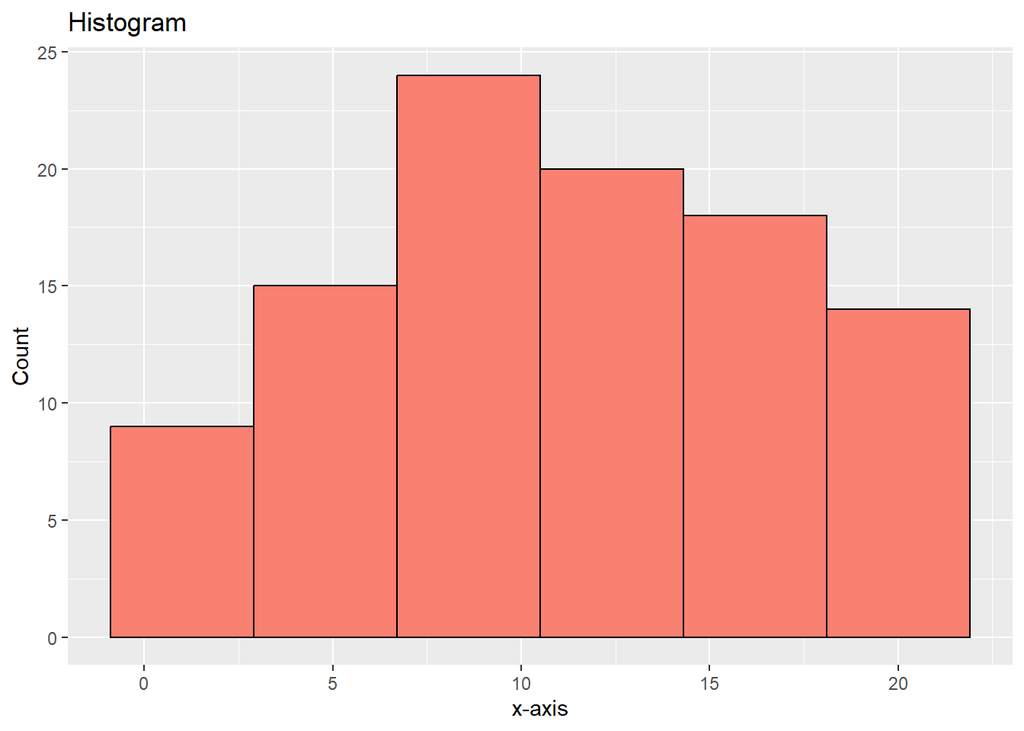

```r
gghist <- function(numeric_vector, bin_number, graph_title = 'Histogram',
                   x_axis = 'x-axis', y_axis = 'Count', title = 'Histogram'){
  if (is.numeric(numeric_vector) == TRUE) { # Make sure vector is numeric

    df <- tibble(numeric_vector)

    #Histogram
    ggplot(data = df, aes(x = numeric_vector)) +
      geom_histogram(color='black', fill='salmon',bins=bin_number) +
      labs(x = x_axis, y = y_axis, title = graph_title)

  } else { # Cancels function for non numeric functions
    print('Use a Numeric Vector')
    return(NULL)
  }
}

gghist(sample(1:20, size = 100, replace = TRUE),
       sample(3:10, size = 1, replace = TRUE))
```

### Box Plot

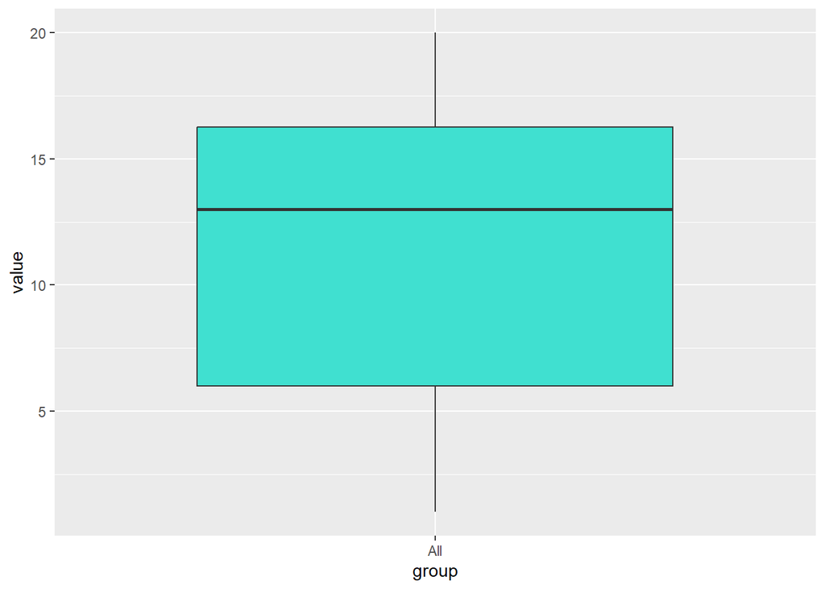

```r
ggbox <- function(numeric_vector, group = NULL, vertical = TRUE) {
  df <- tibble(value = numeric_vector, # Combs inputs
               group = if(is.null(group)) "All" else group
  )
  plot <- ggplot(df, aes(x = group, y = value)) +
    geom_boxplot(fill = "turquoise")
  # Vertical or Horizontal
  if (!vertical) plot <- plot + coord_flip() # Flips the plot

  return(plot)
}

# Tests
ggbox(sample(1:20, size = 100, replace = TRUE))
```

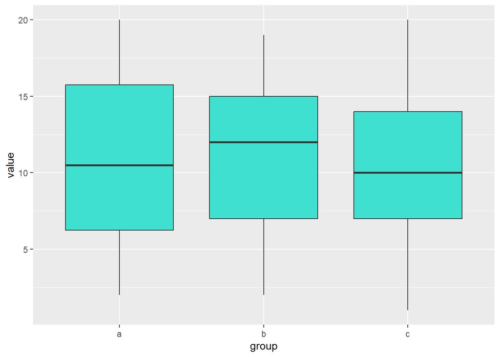

```r
ggbox(sample(1:20, size = 100, replace = TRUE),
      rep(c("a", "b", "c"), length.out = 100))
```

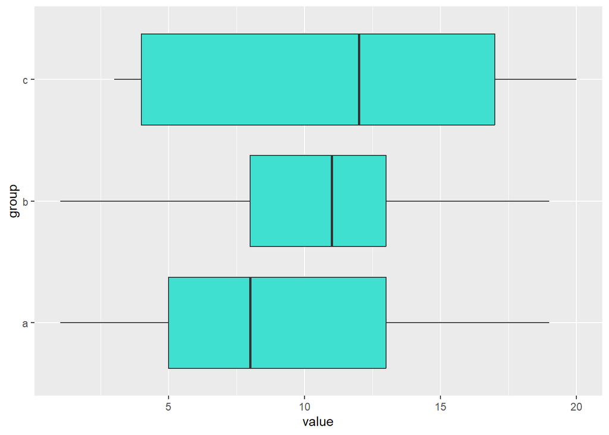

```r
ggbox(sample(1:20, size = 100, replace = TRUE),
      rep(c("a", "b", "c"), length.out = 100), vertical = FALSE)
```

# Problem 2 (57 points)

### Part a (6 points)

```r
# Load the data in
url <- "http://kenpom.com/cbbga26.txt"
bskt_ball = read.fwf(
  file = url,
  widths = c(10, 24, 3, 24, 3, 20),
  col.names = c("Date", "Away", "Away_Score", "Home", "Home_Score", "Location"),
  strip.white = TRUE,
  stringsAsFactors = FALSE
)
# Convert to tibble
cbbga <- tibble(bskt_ball)
head(cbbga)
```

```
# A tibble: 6 × 6
  Date       Away          Away_Score Home              Home_Score Location
  <chr>      <chr>              <int> <chr>                  <int> <chr>
1 11/03/2025 McMurry               55 Abilene Christian         92 ""
2 11/03/2025 James Madison         71 Akron                     85 ""
3 11/03/2025 North Dakota          62 Alabama                   91 ""
4 11/03/2025 Blue Mountain         60 Alabama A&M               80 ""
5 11/03/2025 Florida               87 Arizona                   93 "N   Las Veg…
6 11/03/2025 Southern              77 Arkansas                 109 ""
```

Now lets practice using our tidy data/tidyverse tools! Using your `cbbga` tibble, try doing the following. In each part, save the object as a new tibble (like `cbbga2`, `cbbga3`, etc) and in each subsequent part, use the tibble you created in the previous part.

### Part b (2 points)

Use `rename()` to rename all of your variables to names that make sense. Then print the first six rows of the new tibble using the `head()` function.

```r
cbbga2 <- cbbga |>
  rename(
    date       = Date,
    away_team  = Away,
    away_score = Away_Score,
    home_team  = Home,
    home_score = Home_Score,
    location   = Location
  )

head(cbbga2)
```

```
# A tibble: 6 × 6
  date       away_team     away_score home_team         home_score location
  <chr>      <chr>              <int> <chr>                  <int> <chr>
1 11/03/2025 McMurry               55 Abilene Christian         92 ""
2 11/03/2025 James Madison         71 Akron                     85 ""
3 11/03/2025 North Dakota          62 Alabama                   91 ""
4 11/03/2025 Blue Mountain         60 Alabama A&M               80 ""
5 11/03/2025 Florida               87 Arizona                   93 "N   Las Veg…
6 11/03/2025 Southern              77 Arkansas                 109 ""
```

### Part c (2 points)

Use `mutate()` to create a new column that gives the score differences (home team score minus away team score). Then print the first six rows of the new tibble using the `head()` function.

```r
cbbga3 <- cbbga2 |> mutate(point_difference = home_score - away_score)
head(cbbga3)
```

```
# A tibble: 6 × 7
  date       away_team away_score home_team home_score location point_difference
  <chr>      <chr>          <int> <chr>          <int> <chr>               <int>
1 11/03/2025 McMurry           55 Abilene …         92 ""                     37
2 11/03/2025 James Ma…         71 Akron             85 ""                     14
3 11/03/2025 North Da…         62 Alabama           91 ""                     29
4 11/03/2025 Blue Mou…         60 Alabama …         80 ""                     20
5 11/03/2025 Florida           87 Arizona           93 "N   La…                6
6 11/03/2025 Southern          77 Arkansas         109 ""                     32
```

### Part d (2 points)

Use `arrange()` to sort the data set by the home team alphabetically. Then print the first six rows of the new tibble using the `head()` function.

```r
cbbga4 <- cbbga3 |> arrange(home_team)
head(cbbga4)
```

```
# A tibble: 6 × 7
  date       away_team away_score home_team home_score location point_difference
  <chr>      <chr>          <int> <chr>          <int> <chr>               <int>
1 11/03/2025 McMurry           55 Abilene …         92 ""                     37
2 11/06/2025 Nebraska…         71 Abilene …         73 ""                      2
3 11/11/2025 Southwes…         63 Abilene …        104 ""                     41
4 11/25/2025 William …         92 Abilene …         58 "N   Ja…              -34
5 11/28/2025 Jarvis C…         55 Abilene …         87 ""                     32
6 12/06/2025 New Mexi…         69 Abilene …         77 ""                      8
```

### Part e (2 points)

Use `select()` to remove the extra variable(s) that had that irrelevant information at the end of each line. Note: you can select every variable except one by using `!`. Then print the first six rows of the new tibble using the `head()` function.

```r
cbbga5 <- cbbga4 |> select(!'location')
head(cbbga5)
```

```
# A tibble: 6 × 6
  date       away_team          away_score home_team home_score point_difference
  <chr>      <chr>                   <int> <chr>          <int>            <int>
1 11/03/2025 McMurry                    55 Abilene …         92               37
2 11/06/2025 Nebraska Omaha             71 Abilene …         73                2
3 11/11/2025 Southwestern Adve…         63 Abilene …        104               41
4 11/25/2025 William & Mary             92 Abilene …         58              -34
5 11/28/2025 Jarvis Christian           55 Abilene …         87               32
6 12/06/2025 New Mexico St.             69 Abilene …         77                8
```

### Part f (3 points)

Put parts a-e all together in one piping expression (with 5 pipes) and save this as a new object in **R**.

```r
cbbga6 <- cbbga |>
  rename(
    date       = Date,
    away_team  = Away,
    away_score = Away_Score,
    home_team  = Home,
    home_score = Home_Score,
    location   = Location
  ) |>
  mutate(
    away_score = as.numeric(away_score),
    home_score = as.numeric(home_score),
    point_difference = home_score - away_score
  ) |>
  arrange(home_team) |>
  select(!location)
```

### Part g (3 points)

Use `filter()` to reduce the data down to only games played in 2025 (you could use the `lubridate` package for this, since it specializes in dealing with dates, but some base **R** packages will also work). Save this in a new tibble. **We will use this tibble with only the 2025 years from here on out**.

```r
library(lubridate)

# Convert date to Date format and filter for 2025 games
cbbga7 <- cbbga6 |>
  mutate(date = mdy(date)) |>
  filter(year(date) == 2025)

head(cbbga7)
```

```
# A tibble: 6 × 6
  date       away_team          away_score home_team home_score point_difference
  <date>     <chr>                   <dbl> <chr>          <dbl>            <dbl>
1 2025-11-03 McMurry                    55 Abilene …         92               37
2 2025-11-06 Nebraska Omaha             71 Abilene …         73                2
3 2025-11-11 Southwestern Adve…         63 Abilene …        104               41
4 2025-11-25 William & Mary             92 Abilene …         58              -34
5 2025-11-28 Jarvis Christian           55 Abilene …         87               32
6 2025-12-06 New Mexico St.             69 Abilene …         77                8
```

### Part h (4 points)

Write a function that will filter the tibble to only games played by a given team. Demonstrate your function by displaying games played by SUU in 2025.

```r
team_filter <- function(df, team_name, year_val) {
  df |>
    mutate(
      date = mdy(date),
      home_score = as.numeric(home_score),  # ensure numeric I had issues
      away_score = as.numeric(away_score)
    ) |>
    filter(year(date) == year_val) |>
    filter(away_team == team_name | home_team == team_name)
}

head(team_filter(cbbga6, "Southern Utah", 2025))
```

```
# A tibble: 6 × 6
  date       away_team     away_score home_team      home_score point_difference
  <date>     <chr>              <dbl> <chr>               <dbl>            <dbl>
1 2025-11-04 Southern Utah         64 Arizona St.            81               17
2 2025-11-17 Southern Utah         50 Gonzaga               122               72
3 2025-11-15 Southern Utah         85 Nebraska Omaha         90                5
4 2025-12-18 Southern Utah         57 Northern Ariz…         65                8
5 2025-12-06 Southern Utah         70 Oregon St.             81               11
6 2025-11-28 Southern Utah         54 Robert Morris          61                7
```

### Part i (7 points)

Use `summarize()` to extract SUU’s win/loss record and winning percentage for their 2025 games. Hint: using the `case_when()` function inside of a `mutate()` function to create a new variable that indicates whether SUU won or lost is helpful. You can verify on the Internet that SUU had 4 wins and 10 losses in 2025, so if your code returns those values, you did it correctly.

```r
cbbga8 <- team_filter(cbbga6, "Southern Utah", 2025) |>
  mutate(win_loss = case_when(
    home_team == "Southern Utah" & home_score > away_score ~ "Win",
    home_team == "Southern Utah" & home_score < away_score ~ "Loss",
    away_team == "Southern Utah" & away_score > home_score ~ "Win",
    away_team == "Southern Utah" & away_score < home_score ~ "Loss",
    TRUE ~ "Tie"
  )) |> summarize(
    wins = sum(win_loss == "Win", na.rm = TRUE),
    losses = sum(win_loss == "Loss", na.rm = TRUE),
    win_pct = wins / (wins + losses)
  )

head(cbbga8)
```

```
# A tibble: 1 × 3
   wins losses win_pct
  <int>  <int>   <dbl>
1     4     10   0.286
```

### Part j (7 points)

Generalize this by writing a function that will do this for a given team, and create a tibble with this information for all teams. Arrange this tibble first by winning percentage (descending) and by team (alphabetically) if there are any ties when it comes to winning percentage. A `for` loop and the `add_row()` function may be useful here.

```r
win_loss <- function(team, year) {
  team_filter(cbbga6, team, 2025) |>
  mutate(win_loss = case_when(
    home_team == team & home_score > away_score ~ "Win",
    home_team == team & home_score < away_score ~ "Loss",
    away_team == team & away_score > home_score ~ "Win",
    away_team == team & away_score < home_score ~ "Loss",
    TRUE ~ "Tie"
  )) |> summarize(
    team = team,
    wins = sum(win_loss == "Win", na.rm = TRUE),
    losses = sum(win_loss == "Loss", na.rm = TRUE),
    win_pct = wins / (wins + losses)
  )
}
print(win_loss("Southern Utah", 2025))
```

```
# A tibble: 1 × 4
  team           wins losses win_pct
  <chr>         <int>  <int>   <dbl>
1 Southern Utah     4     10   0.286
```

```r
# Get all teams
teams <- sort(unique(c(cbbga6$home_team)))

# Create the tibble
team_tibble <- tibble(
  team = character(),
  wins = integer(),
  losses = integer(),
  win_pct = numeric()
  )

# For loop that goes through the team list calls the win_loss function for each
for (t in teams) {
  team_tibble <- team_tibble |> add_row(win_loss(t,2025))
}

head(team_tibble)
```

```
# A tibble: 6 × 4
  team               wins losses win_pct
  <chr>             <int>  <int>   <dbl>
1 Abilene Christian     8      5   0.615
2 Air Force             3     10   0.231
3 Akron                10      3   0.769
4 Alabama              10      3   0.769
5 Alabama A&M           7      6   0.538
6 Alabama St.           3     10   0.231
```

### Part k (5 points)

With only the 2025 games, use the `gghist()` you wrote in Problem 1 on the score differences variable you created in part c. Add appropriate labels and a title to your graph. Also, use the `#| fig-width:`, `#| fig-height:`, `#| out-width:`, and `#| fig-align:` code chunk options to center the figure and then to adjust your figure to a size you like. Play around with different sizes to see what those options adjust.

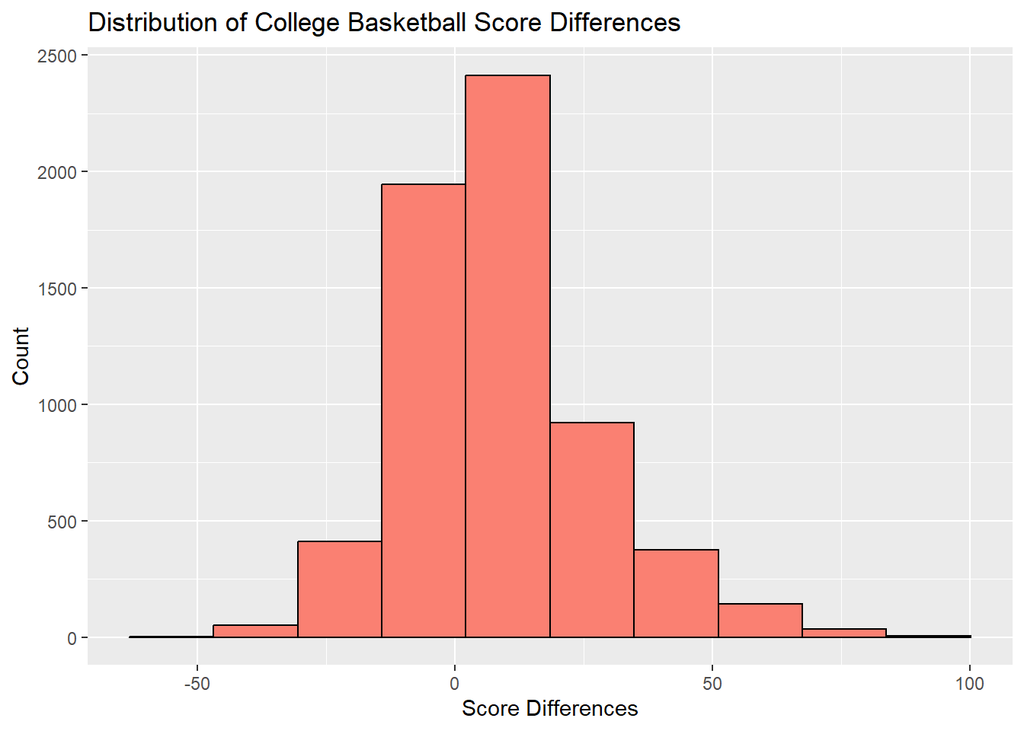

```r
gghist(cbbga6$point_difference, 10,
       'Distribution of College Basketball Score Differences','Score Differences')
```

### Part l (9 points)

Filter the tibble with all 2025 games to only include Utah Tech or Southern Utah, then create a tibble or data frame where each row is a game played by either team that has one column indicating the school, Utah Tech or Southern Utah, and a second column indicating the number of points that team played, regardless of whether the team was home or away. Then use your `ggbox()` function to create a side-by-side boxplot of number of points scored in all 2025 games for each team.

Note, this is a little challenging. The most straightforward way to do this is to use the `pivot_longer()` function with `cols =` the names of the two columns that have the away and the home teams (the names of these columns should not be in quotes, but they should be in a vector `c()`). Try to do this yourself first, but using AI for some help is fine.

```r
lteams <- c('Southern Utah', 'Utah Tech')

# Filter to Southern Utah and Utah Tech
cbbga9 <- cbbga7 |> filter(home_team %in% lteams | away_team %in% lteams) |>
  pivot_longer(
    cols = c(home_team, away_team),
    names_to = "location",
    values_to = "team"
  ) |>
  mutate(points = if_else(location == "home_team",
                           home_score,
                           away_score)) |>
  select(team, points) |>
  filter(team %in% c("Utah Tech", "Southern Utah"))

head(cbbga9)
```

```
# A tibble: 6 × 2
  team          points
  <chr>          <dbl>
1 Utah Tech         67
2 Southern Utah     64
3 Utah Tech         66
4 Utah Tech         69
5 Southern Utah     50
6 Utah Tech         62
```

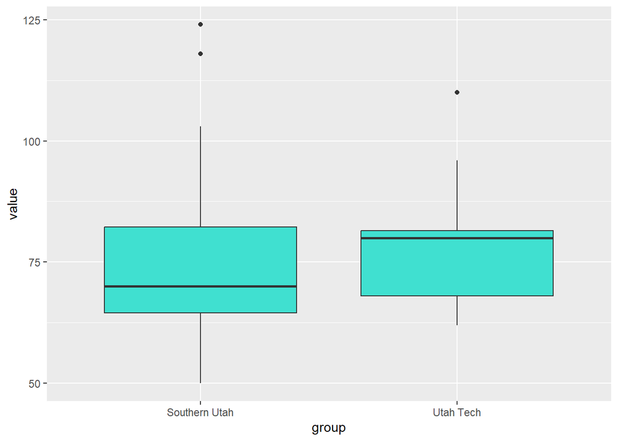

```r
ggbox(cbbga9$points, cbbga9$team)
```

### Part m (5 points)

Create one more appropriate graphs for the 2025 basketball data. This graph could be anything you’d like as long as you use `ggplot2`, it shows something meaningful, and it is not the same as the graphs you made in parts k or l.

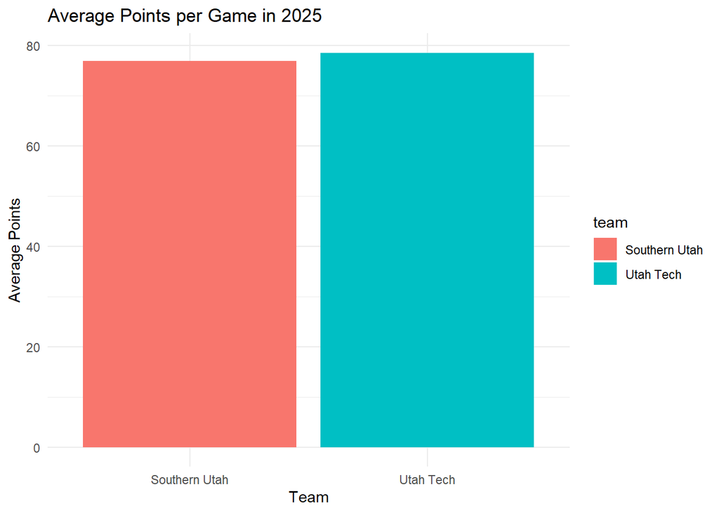

```r
# Part m: Average points per team in 2025
cbbga_summary <- cbbga9 |>
  group_by(team) |>
  summarize(avg_points = mean(points, na.rm = TRUE))

# Bar chart of average points
ggplot(cbbga_summary, aes(x = team, y = avg_points, fill = team)) +
  geom_col() +
  labs(title = "Average Points per Game in 2025", x = "Team", y = "Average Points") +
  theme_minimal()
```

# Problem 3 (15 points)

Repeat parts b-e and g of Problem 2 using Python in Quarto. First, pass the original object that you read in from the website to Python without any changes to it (you do not need to read the file from the web in Python, but you can if you’d like) and then use `pandas` (or `polars` if you’d like) to rename the columns as indicated in part b, add the columns specified in part c, arrange the data as in part d, drop the “garbage” column as in part e, and filter it down as in part g. The `pandas` functions `rename`, `assign` (instead of `mutate`), `drop` (instead of `select`) and `str.contains` (used to select the right rows) will be useful here. Be sure to follow the guide in Notes 3 to properly install Python, install the `pandas` library and to load it in **R**.

```r
# Load reticulate
library(reticulate)
py_config()
```

```
python:         C:/Users/mcmur/AppData/Local/R/cache/R/reticulate/uv/cache/archive-v0/OrWTqCy9-g4Bl3Z4TS4-i/Scripts/python.exe
libpython:      C:/Users/mcmur/AppData/Local/R/cache/R/reticulate/uv/python/cpython-3.12.12-windows-x86_64-none/python312.dll
pythonhome:     C:/Users/mcmur/AppData/Local/R/cache/R/reticulate/uv/cache/archive-v0/OrWTqCy9-g4Bl3Z4TS4-i
virtualenv:     C:/Users/mcmur/AppData/Local/R/cache/R/reticulate/uv/cache/archive-v0/OrWTqCy9-g4Bl3Z4TS4-i/Scripts/activate_this.py
version:        3.12.12 (main, Jan 14 2026, 19:30:21) [MSC v.1944 64 bit (AMD64)]
Architecture:   64bit
numpy:          C:/Users/mcmur/AppData/Local/R/cache/R/reticulate/uv/cache/archive-v0/OrWTqCy9-g4Bl3Z4TS4-i/Lib/site-packages/numpy
numpy_version:  2.4.4

NOTE: Python version was forced by py_require()
```

```r
py_install(packages = 'pandas')
py_install(packages = 'numpy')
py$cbbga <- cbbga
```

```python
import pandas as pd
import numpy as np

df = cbbga.copy()  # make a copy so we don't modify the original

# Part b
df = df.rename(columns={
    'Date': 'date',
    'Away': 'away_team',
    'Away_Score': 'away_score',
    'Home': 'home_team',
    'Home_Score': 'home_score',
    'Location': 'location'
})

# Part c
df['away_score'] = pd.to_numeric(df['away_score'], errors='coerce')
df['home_score'] = pd.to_numeric(df['home_score'], errors='coerce')
df['point_difference'] = df['home_score'] - df['away_score']

# Part d
df = df.sort_values(by='home_team')

# Part e
df = df.drop(columns='location')

# Part g
df['date'] = pd.to_datetime(df['date'], errors='coerce')  # convert to datetime
df_2025 = df[df['date'].dt.year == 2025]

df_2025.head()
```

```
           date               away_team  ...  home_score point_difference
0    2025-11-03                 McMurry  ...          92               37
502  2025-11-11  Southwestern Adventist  ...         104               41
1243 2025-11-25          William & Mary  ...          58              -34
240  2025-11-06          Nebraska Omaha  ...          73                2
1413 2025-11-28        Jarvis Christian  ...          87               32

[5 rows x 6 columns]
```